# Prediction Assignment Writeup

Luis Carlos Méndez

10/17/2022

## Exercise Procedure

As a first step, we load the full R libraries for this project

```r
library(gbm)
library(lattice)
library(dplyr)
library(ggplot2)
library(caret)
library(rpart)
library(rpart.plot)
library(corrplot)
library(rattle)
library(randomForest)
library(RColorBrewer)
library(readr)
```

We store the data hosted on the Web with which the tests and training of the selected algorithms will be done.

```r
  url_train <- "http://d396qusza40orc.cloudfront.net/predmachlearn/pml-training.csv"
  url_quiz  <- "http://d396qusza40orc.cloudfront.net/predmachlearn/pml-testing.csv"

  data_train <- read.csv(url(url_train), strip.white = TRUE, na.strings = c("NA",""))
  data_quiz  <- read.csv(url(url_quiz),  strip.white = TRUE, na.strings = c("NA",""))
```

We check the dimension of the training and test data

```r
  dim(data_train)
```

```
## [1] 19622   160
```

```r
  dim(data_quiz)
```

```
## [1]  20 160
```

From the data downloaded from the WEB, we establish a pair of partitions at $75%$ and $25%$

```r
  in_train  <- createDataPartition(data_train$classe, p=0.75, list=FALSE)
  train_set <- data_train[ in_train, ]
  test_set  <- data_train[-in_train, ]
```

We check the dimension of the partition data

```r
    dim(train_set)
```

```
## [1] 14718   160
```

```r
    dim(test_set)
```

```
## [1] 4904  160
```

The two datasets *train_set and test_set* have a large number of NA values as well as near-zero-variance (NZV) variables. Both will be removed together with their ID variables.

```r
  nzv_var <- nearZeroVar(train_set)
  train_set <- train_set[ , -nzv_var]
  test_set  <- test_set [ , -nzv_var]
```

We verify the dimension of the data with the processing carried out in the previous point

```r
  dim(train_set)
```

```
## [1] 14718   118
```

```r
  dim(test_set)
```

```
## [1] 4904  118
```

Remove variables that are mostly NA. A threshlod of 95 % is selected and verify the dimension.

```r
  na_var <- sapply(train_set, function(x) mean(is.na(x))) > 0.95
  train_set <- train_set[ , na_var == FALSE]
  test_set  <- test_set [ , na_var == FALSE]
```

```r
  dim(train_set)
```

```
## [1] 14718    59
```

```r
  dim(test_set)
```

```
## [1] 4904   59
```

Since columns 1 to 5 are identification variables only, they will be removed as well and check the dimension.

```r
  train_set <- train_set[ , -(1:5)]
  test_set  <- test_set [ , -(1:5)]
```

```r
  dim(train_set)
```

```
## [1] 14718    54
```

```r
  dim(test_set)
```

```
## [1] 4904   54
```

With the processing carried out, a reduction from 160 to 54 variables has been achieved, with which it is possible to improve the processing time.

## Correlation Analysis Procedure

Correlation analysis between the variables before the modeling work itself is done. The “FPC” is used as the first principal component order.

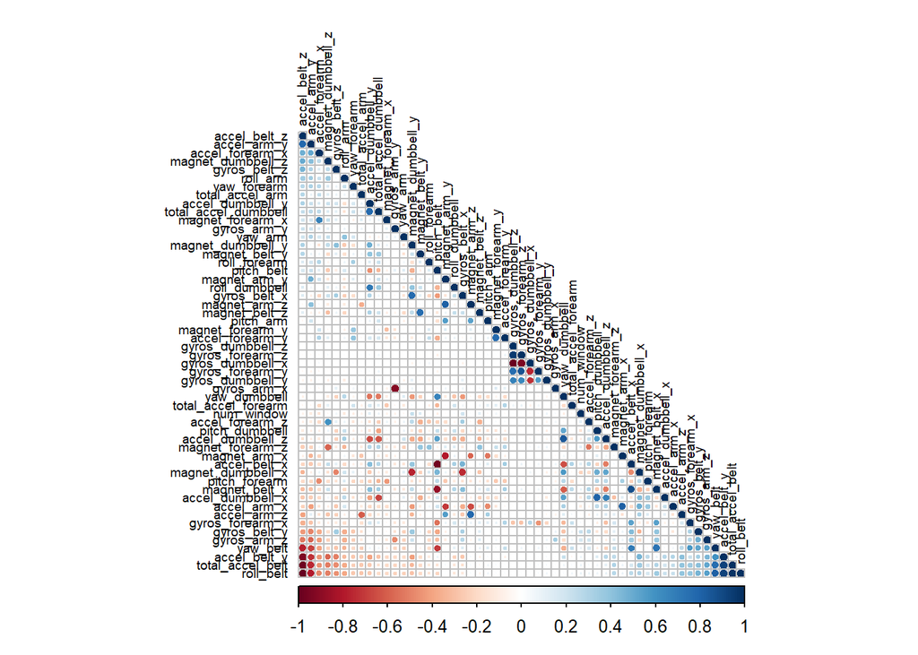

```r
  corr_matrix <- cor(train_set[ , -54])
  corrplot(corr_matrix, order = "FPC", method = "circle", type = "lower", tl.cex = 0.6, tl.col = rgb(0, 0, 0))
```

The interpretation of the correlation plot is that if two variables have a very high correlation, they will be colored in a dark blue, which indicates a positive relationship between variables. On the other hand, if the variables are close to the dark red region, the correlation is negative. As can be seen, there are only a few strong correlations concerning all input variables. The main components of the analysis will not be performed in this analysis. Instead, a few different prediction models will be built for better accuracy.

## Prediction Models

In this part of the project, ML algorithms are used to derive conclusions from the data. For this case study, three techniques are used: Decision Tree, Generalized Boosted Model (GBM), and Random Forest Model. The algorithms and analyzes are listed below.

#Decision Tree Model

For the first algorithm, we perform an analysis under the decision tree approach. The code in R that performs the analysis is shown below

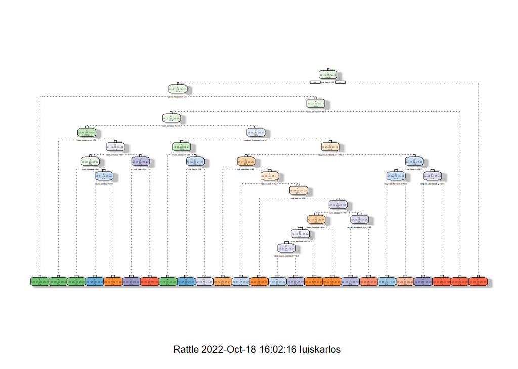

```r
  set.seed(2222)
  fit_decision_tree <- rpart(classe ~ ., data = train_set, method="class")
  fancyRpartPlot(fit_decision_tree)
```

Predictions of the decision tree model on test_set

```r
  predict_decision_tree <- predict(fit_decision_tree, newdata = test_set, type="class")
  conf_matrix_decision_tree <- confusionMatrix(predict_decision_tree, factor(test_set$classe))
  conf_matrix_decision_tree
```

```
## Confusion Matrix and Statistics
##
##           Reference
## Prediction    A    B    C    D    E
##          A 1166   68    2   12    5
##          B  143  722   53   60   39
##          C    0   47  719   22    3
##          D   78   56   76  627   77
##          E    8   56    5   83  777
##
## Overall Statistics
##
##                Accuracy : 0.8179
##                  95% CI : (0.8068, 0.8286)
##     No Information Rate : 0.2845
##     P-Value [Acc > NIR] : < 2.2e-16
##
##                   Kappa : 0.7706
##
##  Mcnemar's Test P-Value : < 2.2e-16
##
## Statistics by Class:
##
##                      Class: A Class: B Class: C Class: D Class: E
## Sensitivity            0.8358   0.7608   0.8409   0.7799   0.8624
## Specificity            0.9752   0.9254   0.9822   0.9300   0.9620
## Pos Pred Value         0.9306   0.7099   0.9090   0.6860   0.8364
## Neg Pred Value         0.9373   0.9416   0.9669   0.9556   0.9688
## Prevalence             0.2845   0.1935   0.1743   0.1639   0.1837
## Detection Rate         0.2378   0.1472   0.1466   0.1279   0.1584
## Detection Prevalence   0.2555   0.2074   0.1613   0.1864   0.1894
## Balanced Accuracy      0.9055   0.8431   0.9116   0.8549   0.9122
```

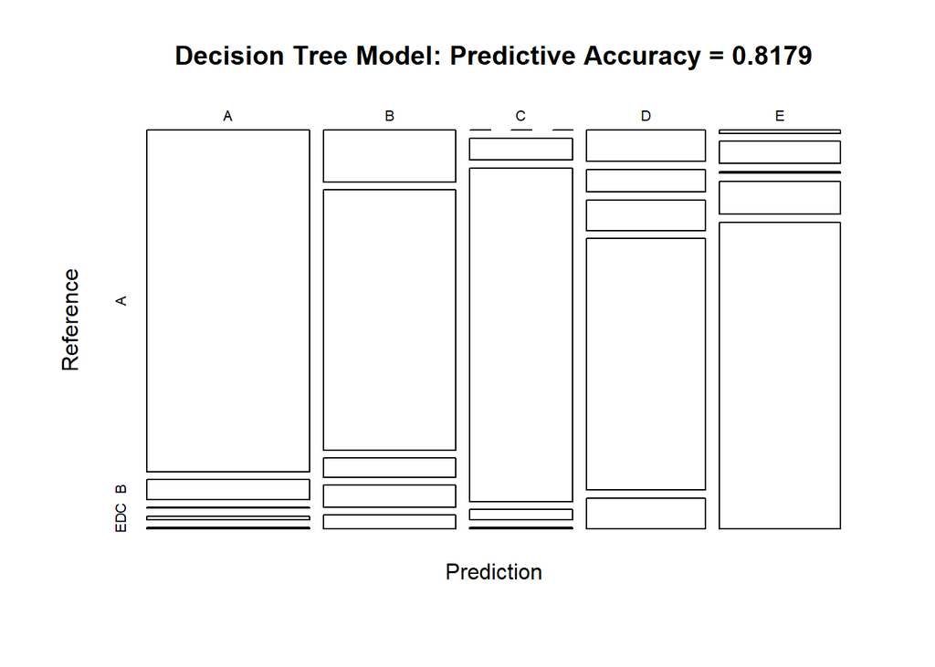

```r
  plot(conf_matrix_decision_tree$table, col = conf_matrix_decision_tree$byClass,
  main = paste("Decision Tree Model: Predictive Accuracy =",
  round(conf_matrix_decision_tree$overall['Accuracy'], 4)))
```

## Generalized Boosted Model (GBM)

```r
  set.seed(2222)
  ctrl_GBM <- trainControl(method = "repeatedcv", number = 5, repeats = 2)
  fit_GBM  <- train(classe ~ ., data = train_set, method = "gbm",trControl = ctrl_GBM, verbose = FALSE)
  fit_GBM$finalModel
```

```
## A gradient boosted model with multinomial loss function.
## 150 iterations were performed.
## There were 53 predictors of which 53 had non-zero influence.
```

Predictions of the GBM on test_set.

```r
  predict_GBM <- predict(fit_GBM, newdata = test_set)
  conf_matrix_GBM <- confusionMatrix(predict_GBM, factor(test_set$classe))
  conf_matrix_GBM
```

```
## Confusion Matrix and Statistics
##
##           Reference
## Prediction    A    B    C    D    E
##          A 1391    5    0    0    0
##          B    3  930   10    7    3
##          C    0   13  841    4    0
##          D    1    1    3  792    5
##          E    0    0    1    1  893
##
## Overall Statistics
##
##                Accuracy : 0.9884
##                  95% CI : (0.985, 0.9912)
##     No Information Rate : 0.2845
##     P-Value [Acc > NIR] : < 2.2e-16
##
##                   Kappa : 0.9853
##
##  Mcnemar's Test P-Value : NA
##
## Statistics by Class:
##
##                      Class: A Class: B Class: C Class: D Class: E
## Sensitivity            0.9971   0.9800   0.9836   0.9851   0.9911
## Specificity            0.9986   0.9942   0.9958   0.9976   0.9995
## Pos Pred Value         0.9964   0.9759   0.9802   0.9875   0.9978
## Neg Pred Value         0.9989   0.9952   0.9965   0.9971   0.9980
## Prevalence             0.2845   0.1935   0.1743   0.1639   0.1837
## Detection Rate         0.2836   0.1896   0.1715   0.1615   0.1821
## Detection Prevalence   0.2847   0.1943   0.1750   0.1635   0.1825
## Balanced Accuracy      0.9979   0.9871   0.9897   0.9913   0.9953
```

## Random Forest Model

Finally, the code with which the Random Forest analysis is performed is presented. Therefore, based on the data presented at the beginning of this document, the results show the following

```r
  set.seed(2222)
  ctrl_RF <- trainControl(method = "repeatedcv", number = 5, repeats = 2)
  fit_RF  <- train(classe ~ ., data = train_set, method = "rf", trControl = ctrl_RF, verbose = FALSE)
  fit_RF$finalModel
```

```
##
## Call:
##  randomForest(x = x, y = y, mtry = param$mtry, verbose = FALSE)
##                Type of random forest: classification
##                      Number of trees: 500
## No. of variables tried at each split: 27
##
##         OOB estimate of  error rate: 0.2%
## Confusion matrix:
##      A    B    C    D    E  class.error
## A 4183    1    0    0    1 0.0004778973
## B    6 2839    2    1    0 0.0031601124
## C    0    6 2561    0    0 0.0023373588
## D    0    0    7 2405    0 0.0029021559
## E    0    0    0    5 2701 0.0018477458
```

Predictions of the random forest model on test_set.

```r
  predict_RF <- predict(fit_RF, newdata = test_set)
  conf_matrix_RF <- confusionMatrix(predict_RF, factor(test_set$classe))
  conf_matrix_RF
```

```
## Confusion Matrix and Statistics
##
##           Reference
## Prediction    A    B    C    D    E
##          A 1395    0    0    0    0
##          B    0  948    2    0    0
##          C    0    1  853    3    0
##          D    0    0    0  801    0
##          E    0    0    0    0  901
##
## Overall Statistics
##
##                Accuracy : 0.9988
##                  95% CI : (0.9973, 0.9996)
##     No Information Rate : 0.2845
##     P-Value [Acc > NIR] : < 2.2e-16
##
##                   Kappa : 0.9985
##
##  Mcnemar's Test P-Value : NA
##
## Statistics by Class:
##
##                      Class: A Class: B Class: C Class: D Class: E
## Sensitivity            1.0000   0.9989   0.9977   0.9963   1.0000
## Specificity            1.0000   0.9995   0.9990   1.0000   1.0000
## Pos Pred Value         1.0000   0.9979   0.9953   1.0000   1.0000
## Neg Pred Value         1.0000   0.9997   0.9995   0.9993   1.0000
## Prevalence             0.2845   0.1935   0.1743   0.1639   0.1837
## Detection Rate         0.2845   0.1933   0.1739   0.1633   0.1837
## Detection Prevalence   0.2845   0.1937   0.1748   0.1633   0.1837
## Balanced Accuracy      1.0000   0.9992   0.9983   0.9981   1.0000
```

The predictive accuracy of the Random Forest model is $99.8\%$

## Conclusion

Based on the statistical evidence shown, the model with the highest accuracy is the Random Forest Model: $99.80\%$. The results above indicate that the Random Forest Model can be applied or make predictions on the 20 data points from the original testing dataset data_quiz. The following R code can achieve the model predictions.

```r
  predict_quiz <- as.data.frame(predict(fit_RF, newdata = data_quiz))
  predict_quiz
```

```
##    predict(fit_RF, newdata = data_quiz)
## 1                                     B
## 2                                     A
## 3                                     B
## 4                                     A
## 5                                     A
## 6                                     E
## 7                                     D
## 8                                     B
## 9                                     A
## 10                                    A
## 11                                    B
## 12                                    C
## 13                                    B
## 14                                    A
## 15                                    E
## 16                                    E
## 17                                    A
## 18                                    B
## 19                                    B
## 20                                    B
```